The Labyrinth of Multiple Testing: how to avoid the pitfall of false positives FDR control Livio Finos

# 1 False Discovery Rate

Consider a set of null hypotheses $\mathcal{H}=(H_1,\ldots,H_m)$, of which an unknown number $m_0$ are true, while the remaining $m_1=m-m_0$ are false. We can summarize the number of errors made by a *multiple testing* procedure in the following table:

| Assumptions | True | False | Total |
| --- | --- | --- | --- |
| rejected | $V$ | $U$ | $R$ |
| not rejected | $m_0 - V$ | $m_1-U$ | $m-R$ |
| total | $m_0$ | $m_1$ | $m$ |

Previously, we had defined the *familywise error rate* as the probability of committing at least one error of the first kind, i.e. $\Pr(V>0)$. Controlling the *familywise error rate* at $\alpha$ requires.
$$\Pr(V>0) = \Pr(Q>0) \leq \alpha$$
We now introduce a new error rate, the *false discovery rate* (FDR), defined as $E(Q)$. Controlling the *false discovery rate* at $\alpha$ requires.
$$E(Q) \leq \alpha.$$

FDR control procedures exert less stringent control than FWER control procedures (such as Bonferroni correction), which seek to control the probability of at least one I-type error,$\Pr(V>0)$ as opposed to controlling the expected value of the proportion of I-type errors $E(Q)$. In fact, since $0\leq Q \leq 1$, we have.
$$E(Q)\leq \Pr(Q>0)$$
which implies that the control of FWER also guarantees the control of FDR. Consequently, we can expect the procedures for checking FDR to be more powerful than the procedures for checking FWER, i.e., to reject more hypotheses.

In practice, methods for checking FDR are particularly more powerful than methods for checking FWER in the presence of many false null hypotheses. In contrast, if all null hypotheses are true, FDR and FWER are identical. In fact, in this case we have $R = V$, so $Q$ is a Bernoulli random variable. It follows that
$$E(Q) = P (Q> 0)$$
Both FDR and FWER are generalizations proper to the concept of error of type I. If there is only one hypothesis ($m = 1$), the two error rates are identical, and equal to the probability of type I error.

# 2 Benjamini-Hochberg procedure.

Let $p_{(1)},\ldots,p_{(m)}$ be the non-decreasingly ordered p-values, i.e., $p_{(1)}leq \ldots \leq p_{(m)}$. For a given $\alpha$,the Benjamini-Hochberg procedure for checking the FDR works as follows:

- If $p_{(i)} > \frac {i\alpha}{m}$ for any $i=1,\ldots,m$, no hypothesis is rejected.
- Otherwise, let
  $$k = \max\Big\{i: p_{(i)} \leq \frac {i\alpha}{m}\Big\i}$$
- one rejects $H_i$ when $p_i \leq \tilde{\alpha}= \Large\frac {k \alpha}{m}$

Under the assumption that the p-values are either. * independent or positively dependent

the Benjamini-Hochberg procedure checks the FDR at the $\pi_0\alpha$ level:
$$E(Q)\leq \pi_0 \alpha \leq \alpha.$$

```r
alpha <- 0.05
pvals <- c(0.03000,0.0002, 0.05912, 0.08226, 0.00388, 0.0184, 0.03490)
m<-length(pvals)
names(pvals)<-LETTERS[1:m]
pvals
```

```
##       A       B       C       D       E       F       G
## 0.03000 0.00020 0.05912 0.08226 0.00388 0.01840 0.03490
```

```r
pvals.ord<-sort(pvals) # p-values sorted
pvals.ord
```

```
##       B       E       F       A       G       C       D
## 0.00020 0.00388 0.01840 0.03000 0.03490 0.05912 0.08226
```

```r
(1:m)[(pvals.ord <= alpha*(1:m)/m)] # indexes i
```

```
## [1] 1 2 3 5
```

```r
k<-max( (1:m)*(pvals.ord <= alpha*(1:m)/m) ) # k = max(indexes i)
k
```

```
## [1] 5
```

```r
alpha.adj<-(alpha*(1:m)/m)[k] # adjusted alpha level
alpha.adj
```

```
## [1] 0.03571429
```

```r
hyps.reject<-names(pvals)[pvals<=alpha.adj] # names hypothesis rejected
hyps.reject
```

```
## [1] "A" "B" "E" "F" "G"
```

Equivalently, we can consider the rejection rule: * we reject the hypothesis $H_{(i)}$ when $\tilde{p}_{(i)} \leq \alpha$

where
$$\tilde{p}_{(i)} = \min_{j=i,\ldots,m}\Big(p_{(j)}\cdot\frac{m}{j}
,1\Big)$$

```r
pvals.ord.adj<-pvals.ord * m/(1:m)
for (i in 1:m){
pvals.ord.adj[i]<-min(pvals.ord.adj[i:m],1)
}
pvals.ord.adj # adjusted p-values
```

```
##          B          E          F          A          G          C          D
## 0.00140000 0.01358000 0.04293333 0.04886000 0.04886000 0.06897333 0.08226000
```

```r
pvals.ord.adj[names(pvals)] # initial sorting
```

```
##          A          B          C          D          E          F          G
## 0.04886000 0.00140000 0.06897333 0.08226000 0.01358000 0.04293333 0.04886000
```

```r
pvals.adj<-p.adjust(pvals,method="BH")
pvals.adj
```

```
##          A          B          C          D          E          F          G
## 0.04886000 0.00140000 0.06897333 0.08226000 0.01358000 0.04293333 0.04886000
```

Graphically we have

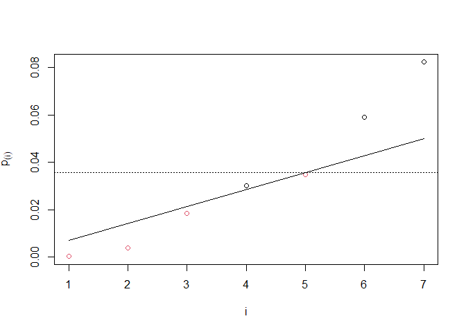

```r
i<-(pvals.ord <= alpha*(1:m)/m)
plot(1:m, pvals.ord, xlab="i", ylab=expression(p[(i)]), col=i+1)
segments(x0=1,y0=alpha/m, x1=m,y1=alpha)
abline(h=alpha.adj, lty="dotted")
```

For comparison, if we use Bonferroni’s method we reject

```r
hyps.reject.Bonf<-names(pvals)[pvals<=alpha/m]
hyps.reject.Bonf
```

```
## [1] "B" "E"
```

# 3 Exercise

```r
m=18
B=1000


simulazione.1.esperimento <- function(){
   # genero la risposta di 6 pazienti su m enpoint
   endpoints=matrix(rnorm(6*m),6,m)
   # aggiunto un valore di 3 ai valori riferiti
   # ai primi 5 endpoint per i tre pazienti con il farmaco new
   endpoints[4:6,1:5]= endpoints[4:6,1:5]+5
   endpoints

   p.values.1.experiment=apply(endpoints , 2, function(y) t.test(y[1:3],y[4:6])$p.value)

   p.bonf <- p.adjust(p.values.1.experiment,method = "bonferroni")
   p.holm <- p.adjust(p.values.1.experiment,method = "holm")
   p.bh <- p.adjust(p.values.1.experiment,method = "BH")

   c(bonf=calcola.err.pow(p.bonf),
     holm=calcola.err.pow(p.holm),
     bh=calcola.err.pow(p.bh))
  }

#### calcola errori e pontenza per una procedura
calcola.err.pow <- function(p.values){
  c(Almeno1errore=any(p.values[-(1:5)]<alpha),
     fdp=sum(p.values[-(1:5)]<alpha)/max(1,sum(p.values<alpha)),
     power=sum(p.values[(1:5)]<alpha)/5)
}

res <- replicate(B,simulazione.1.esperimento())
dim(res)
```

```
## [1]    9 1000
```

```r
res[1:2,1:20]
```

```
##                    [,1] [,2] [,3] [,4] [,5] [,6] [,7] [,8] [,9] [,10] [,11]
## bonf.Almeno1errore    0    0    0    0    0    0    0    0    0     0     0
## bonf.fdp              0    0    0    0    0    0    0    0    0     0     0
##                    [,12] [,13] [,14] [,15] [,16] [,17] [,18] [,19] [,20]
## bonf.Almeno1errore     0     0     0     0     0     0     0     0     0
## bonf.fdp               0     0     0     0     0     0     0     0     0
```

```r
rowMeans(res)
```

```
## bonf.Almeno1errore           bonf.fdp         bonf.power holm.Almeno1errore
##        0.014000000        0.006416667        0.287400000        0.018000000
##           holm.fdp         holm.power   bh.Almeno1errore             bh.fdp
##        0.007283333        0.302600000        0.093000000        0.022573810
##           bh.power
##        0.604800000
```

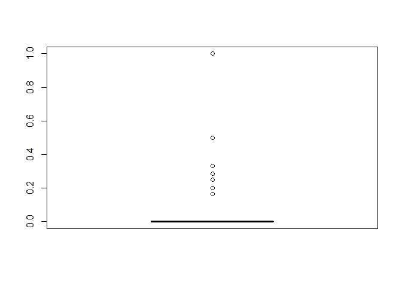

```r
boxplot(res[8,])
```

```r
out=matrix(rowMeans(res),3,3)
colnames(out)=c("bonf","holm","bh")
rownames(out)=c("FWER","FDR","POWER")
out
```

```
##              bonf        holm         bh
## FWER  0.014000000 0.018000000 0.09300000
## FDR   0.006416667 0.007283333 0.02257381
## POWER 0.287400000 0.302600000 0.60480000
```